# Time Series: A First Course with Bootstrap Starter

# Lesson 5-1: ARMA Processes

- ARMA processes generalize the AR and MA processes, and are central to classical time series analysis. They are very useful for modeling and forecasting stationary time series data.

## Definition 5.1.1.

- $\{ X_t \}$ is an ARMA($p$,$q$) process if it is stationary and satisfies
  $$X_t - \sum_{j=1}^p \phi_j \, X_{t-j} = Z_t + \sum_{j=1}^q \theta_j \,
  Z_{t-j},$$
  where $Z_t \sim \mbox{WN} (0,\sigma^2)$. The $\{ Z_t \}$ process is called the *inputs*.
- This is a recursive definition. It requires $p$ initial conditions to start the process.
- An ARMA is like an AR process with MA inputs.
- Special cases: $p=0$ gives an MA($q$), and $q=0$ gives an AR($p$).

## Paradigm 5.1.3. ARMA as a Linear Filter

- We can compactly write the ARMA equation in terms of the backward shift operator $B$. Define the polynomials
  $$\phi (z) = 1 - \sum_{j=1}^p \phi_j z^j \qquad \theta (z) = 1 +
  \sum_{j=1}^q \theta_j z^j.$$
  Then the ARMA process satisfies
  $$\phi (B) X_t = \theta (B) Z_t.$$
- Note that $\phi_0 = 1$ and $\theta_0 = 1$ in these polynomials.

## Example 5.1.4. MA(q) Autocovariance

- Take $p=0$ but $q > 0$, and determine the autocovariance function.
- Suppose $h \geq 0$:
  $${\mathbf E} [ X_t X_{t+h}] = \sum_{j=0}^q \sum_{k=0}^q \theta_j \theta_k
  {\mathbb E} [ Z_{t-j} Z_{t+h-k}]
  = \sum_{j=0}^{q-h} \theta_j \theta_{j+h} \, \sigma^2,$$
  where the sum is interpreted as zero if $q< h$.
- The second equality follows from white noise: ${\mathbb E} [ Z_{t-j} Z_{t+h-k}] = 0$ unless $t-j = t+h -k$, or $j = k-h$. So the double sum collapses to a single sum, setting $k=j+h$.
- But if $h > q$, then it’s impossible for $k = j +h$, because $j +h \geq h > q \geq k$.
- This formula is a convolution of the sequence $\{ \theta_j \}$ with its reverse!

Q here : fully get this convolution stuff

## Exercise 5.14. Product of Polynomials

- We can quickly compute the autocovariance function for an MA process by convolution of the moving average polynomial with its reverse.
- The convolution is also obtained by reading off the product of polynomials.

- We apply this idea to numerically compute the autocovariance for an MA(3) with $\theta(z) = 1 + .4z + .2z^2 - .3z^3$, and $\sigma = 1$.
- First we write a routine to multiply polynomials.

```r
polymul <- function(a,b)
{
    bb <- c(b,rep(0,length(a)-1))
    B <- toeplitz(bb)
    B[lower.tri(B)] <- 0
    aa <- rev(c(a,rep(0,length(b)-1)))
    prod <- B %*% matrix(aa,length(aa),1)
    return(rev(prod[,1]))
}
```

- Then we define the polynomial, and take its product with itself *reversed*.
- This will yield the autocovariance at lags $-3, -2, -1, 0, 1, 2, 3$.

```r
theta <- c(1,.4,.2,-.3)
gamma <- polymul(theta,rev(theta)) # les coeffs et les coeffs à l'envers
print(gamma)
```

```
## [1] -0.30  0.08  0.42  1.29  0.42  0.08 -0.30
```

## Example 5.1.5. MA($\infty$) Process.

- Letting $q = \infty$ in Example 5.1.4, we obtain the important MA($\infty$) process: $X_t = \sum_{j \geq 0} \theta_j Z_{t-j}$.
- Assumes the coefficients satisfy $\sum_{j \geq 0} \theta_j^2 < \infty$.
- The autocovariance function is
  $$\gamma (h) = \sigma^2 \, \sum_{j =0}^{\infty} \theta_j \theta_{j+h}.$$

# Lesson 5-2: Difference Equations

- To understand ARMA processes it is useful to study *difference* equations, which are a discrete analogue of differential equations.

## Definition 5.2.2.

- The equation $\phi (B) X_t = W_t$ is a *linear ordinary difference equation* (ODE) for $\{ X_t \}$ with input $\{ W_t \}$.
- If $\phi (z)$ has degree $p$, then the ODE has order $p$.
- If $W_t \equiv 0$, the ODE is *homogeneous*.

## Paradigm 5.2.7. Solution of a Homogeneous ODE.

- The key is to obtain the roots of $\phi (z)$.
- Why: let $\zeta$ be a root, so that $\phi (\zeta) = 0$. Then check that $X_t = \zeta^{-t}$ solves the homogeneous ODE:
  $$\phi (B) X_t = \sum_{j=0}^p \phi_j X_{t-j} = \sum_{j=0}^p \phi_j
  \zeta^{-t+j}
  = \zeta^{-t} \, \sum_{j=0}^p \phi_j \zeta^j = \zeta^{-t} \, \phi (\zeta)
  = 0.$$
- The polynomial has $p$ roots $\zeta_1, \ldots, \zeta_p$. These can be complex numbers, and might be repeated or distinct.
- If the roots are distinct, the general solution has the format
  $$X_t = \sum_{j=1}^p b_j \zeta_j^{-t},$$
  where $b_j$ are coefficients to be determined by the initial conditions.
- Initial conditions are specified values for $X_1, \ldots, X_p$. If these are real, then the solution $X_t$ for $t > p$ will also be real. (Though the coefficients $b_j$ might be complex.)

## Example 5.2.10. Fibonacci Sequence.

- Consider the Fibonacci recursion $X_t = X_{t-1} + X_{t-2}$, which corresponds to an ODE with $\phi (z) = 1 - z - z^2$.
- The roots are distinct and real: $\zeta_1 = -1/2 + \sqrt{5}/2$, $\zeta_2 = -1/2 - \sqrt{5}/2$.
- With initial conditions $X_1 = X_0 = 1$, the coefficients are found to be $b_1 = -\zeta_2/\sqrt{5}$ and $b_2 = \zeta_1/\sqrt{5}$.
- Then $X_t = b_1 \zeta_1^{-t} + b_2 \zeta_2^{-t}$ is the homogeneous solution.
- We plot the sequence (in log scale) with this initialization.

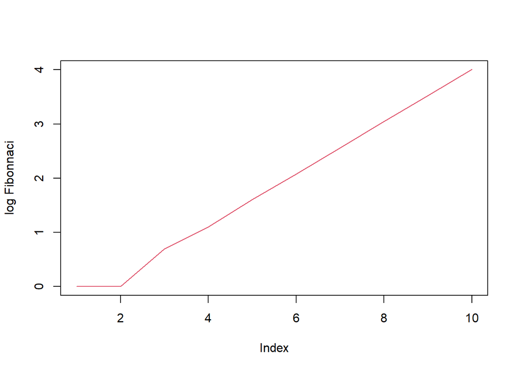

```r
n <- 10
x <- rep(1,n)
for(i in 3:n) { x[i] <- x[i-1] + x[i-2] }
zeta1 <- (-1 + 5^{1/2})/2
zeta2 <- (-1 - 5^{1/2})/2
b1 <- -zeta2/5^{1/2}
b2 <- zeta1/5^{1/2}
y <- b1*zeta1^{-seq(0,n-1)} + b2*zeta2^{-seq(0,n-1)}
plot(ts(log(x)),xlab="Index",ylab="log Fibonnaci")
lines(ts(log(y)),col=2)
```

## Example 5.2.11. Seasonal Difference.

- Any periodic function can be written as a sum of cosines and sines. Why?
- If $X_t$ is periodic with integer period $s$, then it is annihilated by seasonal differencing, and $(1-B^s) X_t = 0$.
- So $\phi(z) = 1 - z^s$, which has roots $\zeta_j = e^{2 \pi i j/s}$ for $j=1,\ldots,s$.
- Thus the solution is
  $$X_t = \sum_{j=1}^s b_j e^{-2 \pi i j t/s}.$$
- If $s$ is even, then two roots (corresponding to $j = s/2, s$) are real, and the rest are complex conjugate pairs.
- If $s$ is odd, then one root (corresponding to $j=s$) is real, and the rest are complex conjugate pairs.
- The sequence $X_t$ is real, so $b_j e^{-2 \pi i j t/s}$ must be real, and hence
  $$X_t = \sum_{j=1}^s {\mathcal R} [b_j] \cos (2 \pi j t/s) + {\mathcal I}
  [b_j]
  \sin (2 \pi j t/s).$$

# Lesson 5-3: Causality of AR(1)

- Causality is the concept that the present value of a time series does not depend on future values, only on present and past values.

## Paradigm 5.3.3. The Causal AR(1) Case.

- From the AR(1) recursion with $|\phi_1| < 1$,
  $$X_t = \phi_1 \, X_{t-1} + Z_t,$$
  and we can recursively solve.
- So we obtain
  $$X_t = \phi_1 \, \left( \phi_1 X_{t-2} + Z_{t-1} \right) + Z_t
  = \phi_1^2 \, X_{t-2} + \phi_1 \, Z_{t-1} + Z_t.$$
- Iterating this argument further, we obtain
  $$X_t = \phi_1^t \, X_0 + \phi_1^{t-1} \, Z_1 + \ldots + \phi_1 \, Z_{t-1}
  + Z_t.$$
- Going further into the past, we obtain
  $$X_t = Z_t + \phi \, Z_{t-1} + \ldots = \sum_{j \geq 0 } \phi_1^j \,
  Z_{t-j}.$$
- So $X_t$ only depends on present and past variables $\{ Z_t \}$. This gives a causal representation.

## Remark 5.3.4.

- The ODE $(1 - \phi_1 B) X_t = Z_t$ is solved by
  $$X_t = \sum_{j \geq 0 } \phi_1^j \, Z_{t-j}.$$
- Check:
  $$X_t = Z_t + \sum_{j \geq 1} \phi_1^j Z_{t-j}
  = Z_t + \sum_{j \geq 0} \phi_1^{j+1} Z_{t-j-1}
  = Z_t + \phi_1 \, \sum_{j \geq 0} \phi_1^j Z_{t-1-j}
  = Z_t + \phi_1 \, X_{t-1}.$$

## Example 5.3.7. Causal AR(1) Autocovariance.

- We see that the causal AR(1) solution corresponds to an MA($\infty$) with $\theta_j = \phi_1^j$.
- Therefore the autocovariance for $h \geq 0$ is given by
  $$\gamma (h) = \sigma^2 \, \sum_{j=0}^{\infty} \phi_1^j \phi_1^{j+h}
  = \sigma^2 \, \phi_1^h \, \sum_{j=0}^{\infty} \phi_1^{2j}
  = \sigma^2 \, \phi_1^h / (1 - \phi_1^2).$$
- So the variance is $\sigma^2/ (1 - \phi_1^2)$, and $\rho (h) = \phi_1^{|h|}$.

# Lesson 5-4: Causality of ARMA

- Causality is a useful concept for forecasting, and can be used to derive the $h$-step ahead forecast filter.

## Definition 5.4.1.

- The ARMA process $\{ X_t \}$ is *causal* with respect to its inputs $\{ Z_t \}$ if there exists a power series $\psi (z) = \sum_{j \geq 0} \psi_j z^j$ such that
  $$X_t = \psi (B) Z_t = \sum_{j \geq 0 } \psi_j \, Z_{t-j}.$$
- This is called the MA($\infty$) representation, since it expresses $\{ X_t \}$ as an MA($\infty$) process.

## Theorem 5.4.3.

- Let $\{ X_t \}$ be an ARMA($p$,$q$) where $\phi(z)$ and $\theta(z)$ have no common roots. Then $\{ X_t \}$ is causal if and only if all the roots of $\phi (z)$ are outside the unit circle, i.e., $|z|>1$ when $\phi (z) = 0$. In this case,
  $$\psi (z) = \sum_{j \geq 0} \psi_j z^j = \frac{ \theta (z) }{ \phi (z)}.$$
- The coefficients $\psi_j$ can be computed by recursions, by partial fraction decomposition, or by the theory of ODE.

## Remark 5.4.5. Common Roots.

- If the AR and MA polynomials had a common root, it could be cancelled from both polynomials, yielding a simplified difference equation.
- For example: $X_t - .5 X_{t-1} = Z_t - .5 Z_{t-1}$ has the solution $X_t = Z_t$, given by cancellation.

## Exercise 5.26. Cancellation in an ARMA(1,2).

- Suppose that $X_t - .5 X_{t-1} = Z_t - 1.3 Z_{t-1} +.4 Z_{t-2}$.
- This is equivalent to an MA(1) process: $\phi(z) = 1-.5z$, and
  $$\theta (z) =1 - 1.3 z + .4z^2 = (1 - .5z) (1-.8z).$$
- Thus $X_t = Z_t - .8 Z_{t-1}$.

# Lesson 5-5: Invertibility of ARMA

- Some processes also have an infinite order *autoregressive* representation.

## Definition 5.5.1.

- The ARMA process $\{ X_t \}$ is *invertible* with respect to its inputs $\{ Z_t \}$ if there exists a power series $\pi (z) = \sum_{j \geq 0} \pi_j z^j$ such that
  $$Z_t = \pi (B) X_t = \sum_{j \geq 0 } \pi_j \, X_{t-j}.$$
- This is called the AR($\infty$) representation, since it represents $\{ X_t \}$ as an autoregressive process of infinite order.
- Invertibility is crucial for prediction applications, because it guarantees the non-singularity of certain covariance matrices needed for prediction.

## Theorem 5.5.3.

- Let $\{ X_t \}$ be an ARMA($p$,$q$) where $\phi(z)$ and $\theta(z)$ have no common roots. Then $\{ X_t \}$ is invertible if and only if all the roots of $\theta (z)$ are outside the unit circle, i.e., $|z|>1$ when $\theta (z) = 0$. In this case,
  $$\pi (z) = \sum_{j \geq 0} \pi_j z^j = \frac{ \phi (z) }{ \theta (z)}.$$
- The coefficients $\pi_j$ can be computed by recursions, by partial fraction decomposition, or by the theory of ODE.

## Example 5.5.7. ARMA(1,2) Process

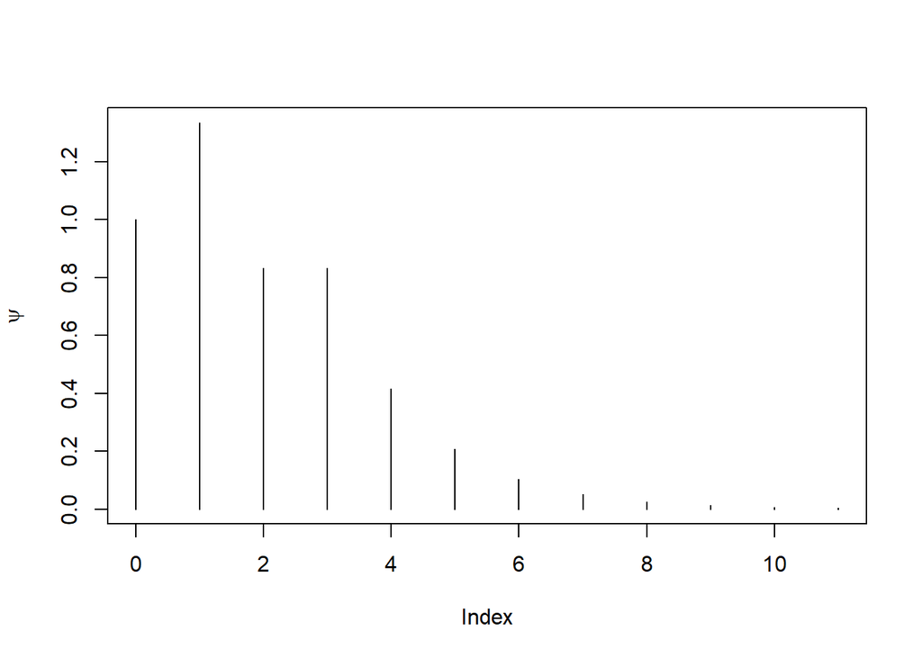

```r
psi <- c(1,4/3,5/6,(10/3)*(1/2)^seq(2,10))
plot(ts(psi,start=0),type="h",xlab="Index",ylab=expression(psi))
```

- Since the roots of $\theta(z)$ are $z=-2,-3$, which have magnitude larger than one, the process is invertible. Then
  $$\theta (z) \pi(z) = \phi (z).$$
  By matching coefficients,
  $$\pi_k + (5/6) \pi_{k-1} + (1/6) \pi_{k-2} = \begin{cases} 1 \qquad
  \mbox{if} \; k = 0 \\
  -1/2 \quad \mbox{if} \; k = 1 \\ 0 \qquad \mbox{if} \; k \geq 2
  \end{cases}$$
  for $k \geq 0$, where $\pi_k = 0$ if $k < 0$. Solving recursively, we get
  $$\begin{align*}
  \pi_0 & = 1 \\
  \pi_1 & = -4/3 \\
  \pi_k & = -(5/6) \pi_{k-1} - (1/6) \pi_{k-2} \qquad k \geq 2.
  \end{align*}$$

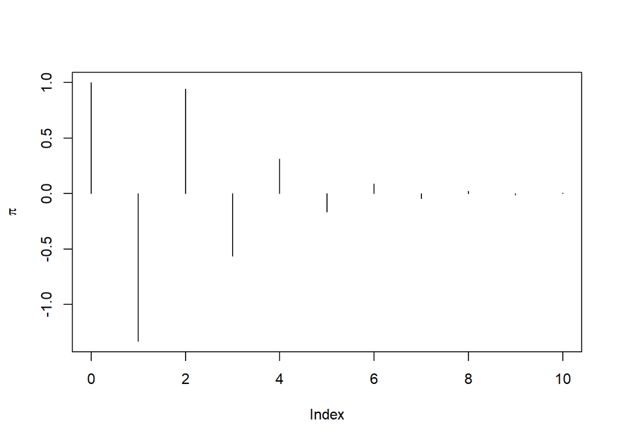

```r
pi <- c(1,-4/3)
for(j in 2:10)
{
  pi <- c(pi,(-5/6)*pi[j]+(-1/6)*pi[j-1])
}
plot(ts(pi,start=0),type="h",xlab="Index",ylab=expression(pi))
```

# Lesson 5-6: Autocovariance Generating Function

- We want a way to summarize the autocovariances for an ARMA process.

## Definition 5.6.1.

The *autocovariance generating function* (AGF) of a stationary time series with autocovariance function $\gamma (k)$ is
$$G(z) = \sum_{k = - \infty}^{\infty} \gamma (k) z^k$$
(if it converges in some annulus $1/r < |z| < r$ for $r > 1$).

## Example 5.6.3. Constant AGF

- Suppose $X_t \sim \mbox{WN}(0, \sigma^2)$. Then $\gamma (0) = \sigma^2$, and $\gamma (k) = 0$ if $k \neq 0$. Hence
  $$G(z) = \gamma (0) = \sigma^2.$$
- The AGF for white noise is a constant function.

## Definition 5.6.5.

- Suppose that $Y_t = \psi (B) X_t$ for some linear filter $\psi (B)$. For complex $z$, the *transfer function* of the filter is $\psi (z)$. Its coefficients $\psi_j$ are the *impulse response coefficients*.

## Theorem 5.6.6.

Suppose we filter stationary $\{ X_t \}$ with some $\psi (B)$, yielding $Y_t = \psi (B) X_t$. Then the AGFs of input and output are related by
$$G_y (z) = \psi (z) \psi (z^{-1}) G_x (z).$$

## Remark 5.6.8. ARMA Transfer Function

- Because a causal ARMA can be written in MA representation as $X_t = \psi (B) Z_t$, we have
  $$G_x (z) = \psi (z) \psi (z^{-1}) \sigma^2,$$
  by Example 5.6.3.
- Using $\psi (z) = \theta (z)/ \phi (z)$, we obtain
  $$G_x (z) = \frac{ \theta (z) \theta (z^{-1}) }{ \phi (z) \phi (z^{-1}) }
  \sigma^2.$$

## Example 5.6.9. MA(1) AGF

- We can use the AGF to compute autocovariances from MA parameters.
- Suppose $\{ X_t \}$ is an MA(1) process with polynomial $\theta(z) = 1 + \theta_1 z$. Then
  $$G_x (z) = \theta (z) \theta (z^{-1}) \sigma^2
  = (1 + \theta_1 z) (1 + \theta_1 z^{-1}) \sigma^2
  = \left( 1 + \theta_1^2 + \theta_1 z + \theta_1 z^{-1} \right) \sigma^2.$$
- Because the coefficient of $z^0 = 1$ is $\gamma (0)$, we have
  $$\gamma (0 ) = (1 + \theta_1^2) \sigma^2.$$
- Also, the coefficient of both $z$ and $z^{-1}$ is $\gamma (1)$. Therefore
  $$\gamma (1) = \theta_1 \sigma^2.$$

## Example 5.6.10. AR(1) AGF

- We can also compute the AGF for an AR(1).
- Suppose $\{ X_t \}$ is an AR(1) with causal polynomial $\phi (z) = 1 - \phi_1 z$. Then
  $$G_x (z) = \frac{1}{ \phi (z) \phi (z^{-1})} \sigma^2
  = \frac{1}{ (1 - \phi_1 z) (1 - \phi_1 z^{-1})} \sigma^2.$$
- By geometric series,
  $${(1 - \phi_1 z)}^{-1} = \sum_{j \geq 0} \phi_1^j z^j.$$
  (Causality guarantees that $|\phi_1| < 1$!)
- Therefore
  $$\begin{align*}
  G_x (z) & = \left( \sum_{j \geq 0} \phi_1^j z^j \right)
  \left( \sum_{j \geq 0} \phi_1^j z^{-j} \right) \sigma^2 \\
  & = \sum_{j,k \geq 0} \phi_1^{j+k} z^{j-k} \sigma^2 \\
  & = \sum_{h = -\infty}^{\infty} \sum_{k \geq 0} \phi_1^{|h| + 2k}
  z^h \sigma^2 \\
  & = \sum_{h = -\infty}^{\infty} \frac{ \phi_1^{|h|}}{1 - \phi_1^2}
  z^h \sigma^2.
  \end{align*}$$
- Now we read off the coefficient of $z^h$ (or $z^{-h}$) is $\gamma (h)$:
  $$\gamma (h) = \frac{ \phi_1^{|h|}}{1 - \phi_1^2} \sigma^2.$$

# Lesson 5-7: MA Representation

- We know the autocovariances of an MA process, but how about an ARMA?
- Given the ARMA polynomials $\theta (z)$ and $\phi (z) = 1 - \sum_{j=1}^p \phi_j z^j$, we need algorithms to compute the autocovariances.

## Paradigm 5.7.1. Method 1 for ARMA Autocovariances

- First determine the coefficients of $\psi (z)$, the MA representation. Then compute
  $$\gamma (h) = \sum_{j \geq 0 } \psi_j \psi_{j+|h|} \sigma^2,$$
  which follows from the AGF.
- We get $\psi_j$ recursively by using $\psi (z) \phi (z) = \theta (z)$, so that the $\theta_j$ coefficients equal the convolution of $\psi_j$ and $\phi_j$.
- Letting $\phi_j = 0$ for $j > p$ and $\theta_j =0$ for $j > q$, we obtain
  $$\psi_j = \theta_j + \sum_{k=1}^j \phi_k \psi_{j-k}.$$
- We can also obtain a direct formula using ODE theory.

## Example 5.7.2. Cyclic ARMA(2,1) Process

- We define an ARMA(2,1) process with cyclic properties.
- For $\rho \in (0,1)$ and $\omega \in (0,\pi)$, let $\{ X_t \}$ satisfy
  $$( 1 - 2 \rho \cos (\omega) B + \rho^2 B^2) X_t = (1 - \rho \cos (\omega)
  B) Z_t.$$
- The roots of $\phi (z) = 1 - 2 \rho \cos(\omega) z + \rho^2 z^2$ are $\rho^{-1} e^{\pm i \omega}$.
- We use ODE theory with initial conditions $\psi_0 = 1$,
  $$\psi_1 = \theta_1 + \psi_0 \phi_1 = \rho \cos (\omega),$$
  and eventually find $\psi_j = \rho^j \cos (\omega j)$ for $j \geq 0$.

```r
rho <- .95
omega <- pi/5
lag <- 60
psi <- (rho^(seq(1,lag)-1))*cos((seq(1,lag)-1)*omega)
```

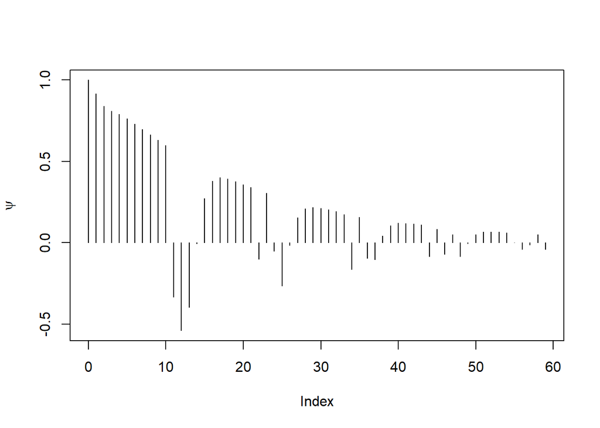

```r
plot(ts(psi,start=0),type="h",xlab="Index",ylab=expression(psi))
```

- From the MA($\infty$) representation, we obtain the autocovariance:
  $$\gamma (k) = \frac{ \sigma^2}{2} \, \rho^k \,
  \left( \frac{ \cos (\omega k) }{1 - \rho^2} +
  \frac{ \cos (\omega k) - \rho^2 \cos ( \omega (k-2)) }{ 1 - 2 \rho^2
  \cos (2 \omega) + \rho^4 } \right).$$
- We rewrite this formula slightly and implement in R.

```r
const1 <- 1/(1-rho^2) + (1 - rho^2*cos(2*omega))/(1 - 2*rho^2*cos(2*omega) + rho^4)
const2 <- rho^2*sin(2*omega)/(1 - 2*rho^2*cos(2*omega) + rho^4)
gamma <- .5*(rho^(seq(1,lag)-1))*(cos((seq(1,lag)-1)*omega)*const1 - sin((seq(1,lag)-1)*omega)*const2)
gamma <- gamma/(const1/2)
```

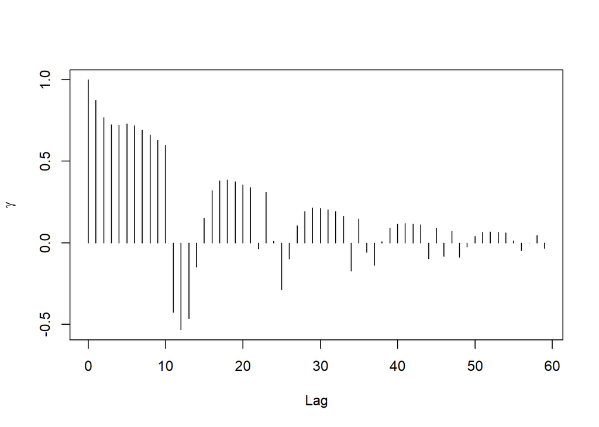

```r
plot(ts(gamma,start=0),type="h",xlab="Lag",ylab=expression(gamma))
```

# Lesson 5-8: Recursive Computation of Autocovariance

- A second technique finds the autocovariances without first finding the MA representation.

## Paradigm 5.8.1. Method 2 for ARMA Autocovariances

- Determine a recursive relation for the $\gamma (h)$:
  $$\gamma (k) - \sum_{j=1}^p \phi_j \gamma (k-j) = \begin{cases} \sigma^2
  \sum_{j=0}^{q-k} \theta_{j+k} \psi_j \quad \mbox{if} \; k \leq q \\
  0 \qquad \mbox{if} \; k > q.
  \end{cases}$$
- This is compactly written as $\phi (B) \gamma_k = 0$ for $k > q$, an ODE in terms of the autocovariance function.
- To solve, we find the roots of $\phi (z)$ and determine the homogeneous solution, using initial conditions for $\gamma_k$.
- If the roots $\zeta_j$ of $\phi (z)$ are distinct, then
  $$\gamma (k) = \sum_{j=1}^p b_j \zeta_j^{-k}$$
  for coefficients $b_j$.
- These initial conditions can be recursively determined, using other expressions for ${\mathbb E} [ W_t X_{t-h}]$, where $W_t = \phi(B) X_t$ (this is the “moving average” portion of the ARMA process).

## Proposition 5.8.3. Exponential Decay of ARMA ACF.

Consider a stationary ARMA($p$,$q$) process such that $\phi (B) X_t = \theta (B) Z_t$, for $Z_t \sim \mbox{WN} (0, \sigma^2)$. Assume $\phi$ and $\theta$ have no common roots. Then there exists a constant $C>0$ and $r \in (0,1)$ such that
$$|\gamma (k) | \leq C r^{|k|}$$
for all $|k| \geq \max \{ p, q+1 \}$. Hence the ACF exists.

## Exercise 5.51. Direct Algorithm for Autocovariance Function for the ARMA($p$,$q$)

- We encode the second method and run on Example 5.5.7.
- This encoding is *ARMAauto.r*. Most of the code has to do with computing the initial values of the autocovariance, and the latter part of the code has the recursion.

```r
polymult <- function(a,b) {
bb <- c(b,rep(0,length(a)-1))
B <- toeplitz(bb)
B[lower.tri(B)] <- 0
aa <- rev(c(a,rep(0,length(b)-1)))
prod <- B %*% matrix(aa,length(aa),1)
return(rev(prod[,1]))
}

ARMAauto <- function(phi,theta,maxlag)
{
    p <- length(phi)
    q <- length(theta)
    gamMA <- polymult(c(1,theta),rev(c(1,theta)))
    gamMA <- gamMA[(q+1):(2*q+1)]
    if (p > 0)
    {
        Amat <- matrix(0,nrow=(p+1),ncol=(2*p+1))
        for(i in 1:(p+1))
        {
            Amat[i,i:(i+p)] <- c(-1*rev(phi),1)
        }
        Amat <- cbind(Amat[,(p+1)],as.matrix(Amat[,(p+2):(2*p+1)]) +
            t(matrix(apply(t(matrix(Amat[,1:p],p+1,p)),2,rev),p,p+1)))
        Bmat <- matrix(0,nrow=(q+1),ncol=(p+q+1))
        for(i in 1:(q+1))
        {
            Bmat[i,i:(i+p)] <- c(-1*rev(phi),1)
        }
        Bmat <- t(matrix(apply(t(Bmat),2,rev),p+q+1,q+1))
        Bmat <- matrix(apply(Bmat,2,rev),q+1,p+q+1)
        Bmat <- Bmat[,1:(q+1)]
        Binv <- solve(Bmat)
        gamMix <- Binv %*% gamMA
        if (p <= q) { gamMix <- matrix(gamMix[1:(p+1),],p+1,1)
            } else gamMix <- matrix(c(gamMix,rep(0,(p-q))),p+1,1)
        gamARMA <- solve(Amat) %*% gamMix
    } else gamARMA <- gamMA[1]

    gamMA <- as.vector(gamMA)
    if (maxlag <= q) gamMA <- gamMA[1:(maxlag+1)] else gamMA <- c(gamMA,rep(0,(maxlag-q)))
    gamARMA <- as.vector(gamARMA)
    if (maxlag <= p) gamARMA <- gamARMA[1:(maxlag+1)] else {
    for(k in 1:(maxlag-p))
    {
        len <- length(gamARMA)
        acf <- gamMA[p+1+k]
        if (p > 0) acf <- acf + sum(phi*rev(gamARMA[(len-p+1):len]))
        gamARMA <- c(gamARMA,acf)
    } }
    return(gamARMA)
}
```

- We illustrate with particular settings.

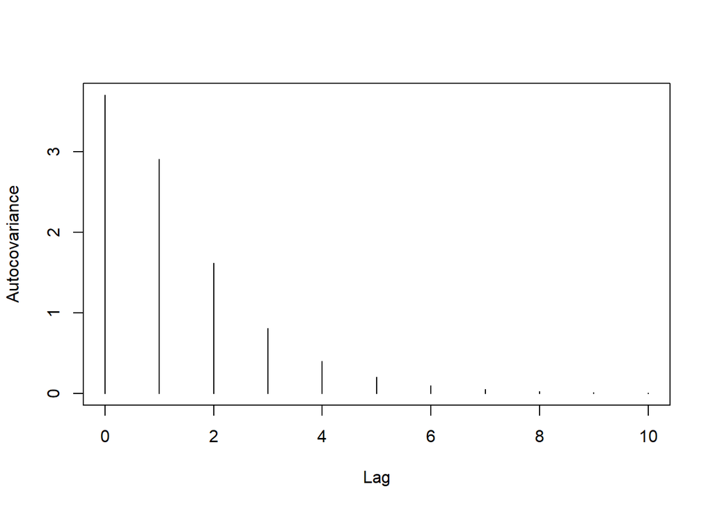

```r
phi1 <- .5
theta1 <- 5/6
theta2 <- 1/6
sigma <- 1
n <- 10
my.acf <- ARMAauto(phi1,c(theta1,theta2),n)*sigma^2
plot(ts(my.acf,start=0),xlab="Lag",ylab="Autocovariance",
     ylim=c(min(my.acf),max(my.acf)),type="h")
```